# Visualizing Classifier Performance

March 1, 2018

## Goals

- Foster interest in CS 285, MAT 470, and Data Science Minor (all new)
- Demonstrate machine learning and data visualization techniques
- Share some of what I'm interested in

  -Slides will be available on http://jpreszler.rbind.io

## Background: Classification and Class Imbalance

## Classification

- Classification problems predict which category an item belongs to.
- Examples:
  - *Is email spam?*
  - *Which of 5 people wrote this paper?*
  - *Is this transaction fraudulent?*
- This is one of the pillars of machine learning.

## Class Imbalance

- When distribution of categories is highly skewed,  
  we have **class imbalance**
- This makes classification harder.
- Our problem: *given data on irreducible cubic polynomial \(f(x)\), will \(f\circ f(x)\) be irreducible?*
- Data: over \(200\) million irreducible cubics, \(75\) have reducible iterates.

## Machine Learning Process

## Machine Learning Workflow

- Get data: C with FLiNT and OpenMP to build data set.
- Build Training Set (typically \(60\% - 80\%\) of data)
- Build Test Set (the rest of data)
- Use training set to build model(s), measure performance using test set.

## Typical Imbalance Solution

- Rebalance by inflating rate of low-class cases in training set.
- Keep test set class distribution similar to real-world.
- But how much should we adjust class distributions by?

## My Process

## Build Sets

- Read data in with data.table
- Remove duplicates
- Build 21 training sets
- Each has same 52 ER cases
- Number of non-ER varies from 500 to 2500 by 100
- Non-ER cases are sampled from main dataset
- One test set, 23 ER cases and 8000 non-ER

## Build NER R code

mkNER.R:

```r
  bigNER <- fread(bigFile, header=TRUE, sep=",")
  bigNER <- bigNER[!duplicated(bigNER) & bigNER$numFact==1,]

    samps <- sapply(nerSize, function(x) sample(1:n, x,
                                            replace = FALSE))
    nerss <- map(samps, function(x) bigNER[x,])
    for(i in 1:length(nerSize)){
      trsName <- paste(paste("NERtrain",nerSize[i],
                             sep = "-"),"csv",sep=".")
      write.csv(nerss[[i]],trsName, row.names = FALSE)
    }
```

## Building Training Sets

```r
  erIDX <- sample(1:length(er$cube), .7*length(er$cube), replace=FALSE)
  for(i in nerTrainFiles){
    ner <- loadTT(i)
    ner <- separate(ner, poly,
              into=c("len","const","lin","quad","cube"),
                sep="[[ ]]+") %>% dplyr::select(c(-len,-content))
    tr <- rbind.data.frame(ner, er[erIDX,])
    write.csv(tr, paste(paste("train", length(ner$cube),
                    sep="-"), "csv",sep="."),row.names=FALSE)
    rm(ner)
    rm(tr)
  }
```

## Model Building

For each of the 21 training sets, we'll build 9 models

- 3 logistic regression with **regularization** (glmnet)
- 4 random forests
- naive bayes, knn
- That's 189 models!
- Each model build using 10-fold cross validation and "Kappa" error metric
- Need Parallelization to train multiple models at once, and multiple CV runs

## CV and Kappa

- Cross-validation:
  - split training set into mini-training/test set pairs
  - build model and check model on mini-sets with different hyperparameter values
  - build model on full training set using hyperparameters with "best" error metric
- Kappa:
  - Standard error metric for imbalanced classifiers
  - Compares observed accuracy with what's expected from random chance.

## Model Building Code

One of the models:

```r
library(caret)
library(doParallel)
  cl <- makeCluster(detectCores())
  registerDoParallel(cl)

 tr1.rfs <- train(numFact~const+lin+quad+cube+nSign+pSign+sigReal,
                  data=trs1, method="rf", metric = "Kappa",
                  trControl = trainControl(method="cv",
                              number = 10, allowParallel = TRUE))

 tst$rfs <- predict(tr1.rfs, tst, type = "prob")[,2]

  stopCluster(cl)
```

## Model Performance

## Confusion Matrices

| Predicted vs. Actual | Act. 1 | Act. 2 |
| --- | --- | --- |
| Pred. 1 | TN | FN |
| Pred. 2 | FP | TP |

- Assign prediction class from probabilities \(p\) of having 2 factors by checking \(p \ge \theta\).

## Confusion Data Frame

Sample of Data Frame with 1134 confusion matrices!

| mdl | TN | TP | FP | FN | ner | theta |
| --- | --- | --- | --- | --- | --- | --- |
| lrs | 7862 | 1 | 138 | 22 | 600 | 0.50 |
| lrp | 7382 | 13 | 618 | 10 | 700 | 0.20 |
| lrsq | 7900 | 5 | 100 | 18 | 2100 | 0.30 |
| knn | 7876 | 17 | 124 | 6 | 800 | 0.50 |
| lrs | 7761 | 8 | 239 | 15 | 1600 | 0.15 |
| rfpp | 7943 | 10 | 57 | 13 | 2000 | 0.40 |

## Visualizing Performance

## ROC: Receiver Operating Characteristic

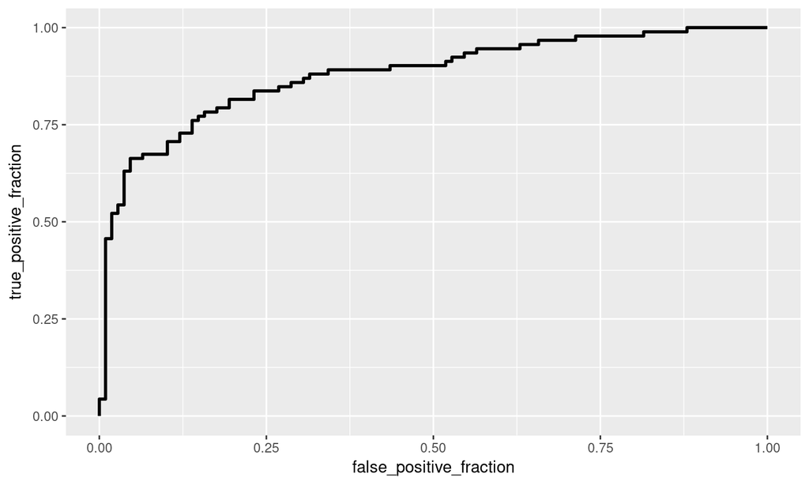

## ROC: Fix ner, vary \(\theta\)

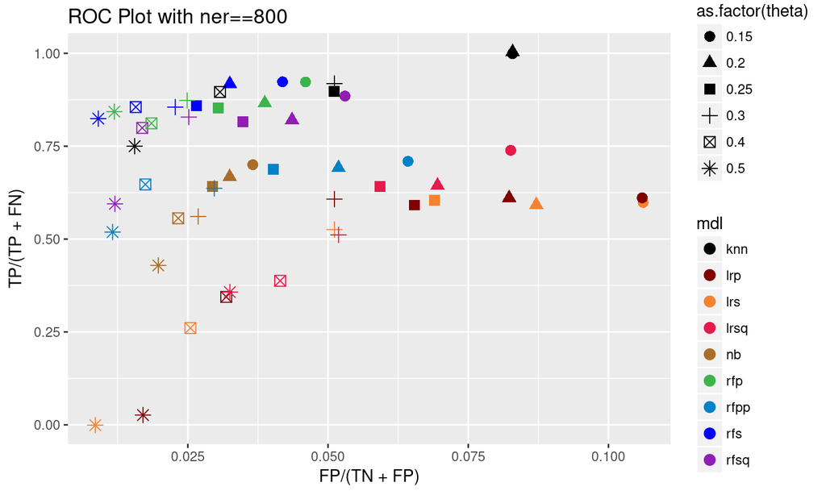

## ROC: Fix \(\theta\), vary ner

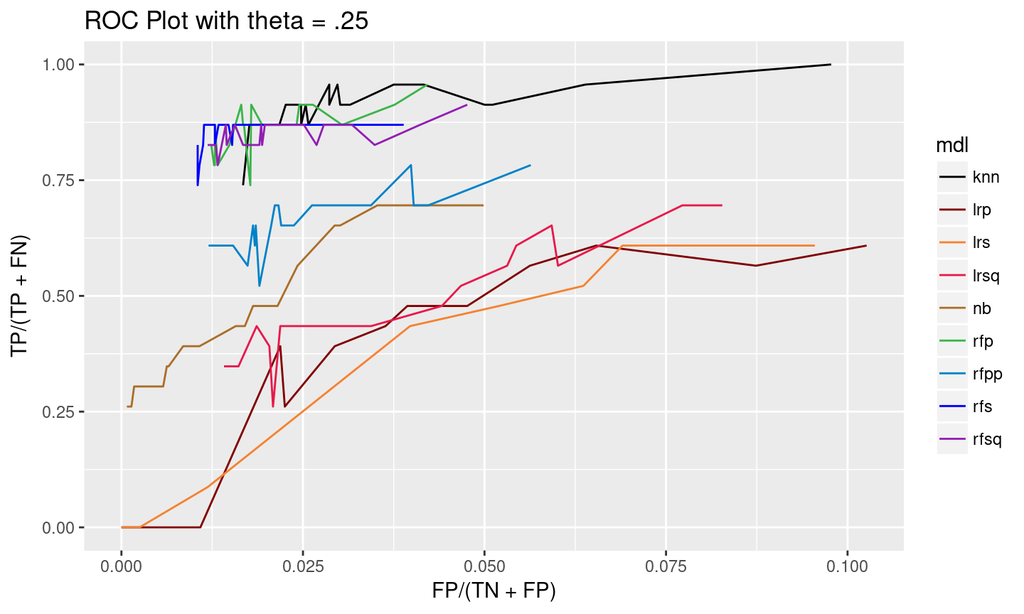

## Animated ROC

[figure not shown]

aniroc

[figure not shown]

anirocft

## ROC Summary

- Generally knn followed by some of the random forest models find the most cases of emergent reducibility
- Higher theta, and higher class imbalance causes models to generally perform worse
- exact changes depend on the model
- Logistic Regression most susceptible to noise
- see post on http://jpreszler.rbind.io to see comparison without regularization on logistic regression.
- ROC helps compare models, theta threshold, and class imbalance
- But which polynomials are found by each model?

## Heatmaps

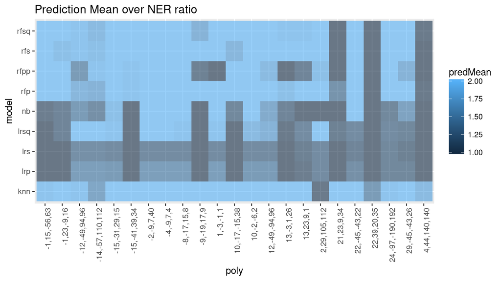

## Animated Heatmaps

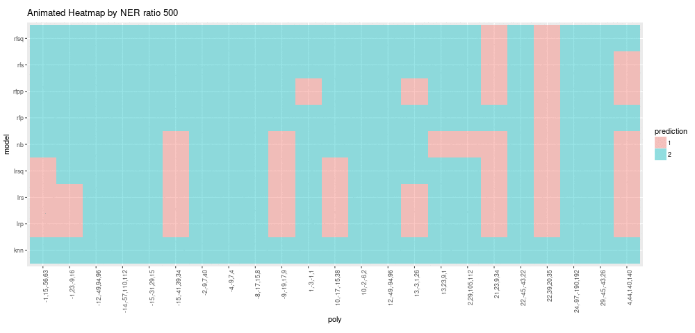

## Future Plans

-Model Critique:

```
-Why are certain ER polynomials missed?
-Why are others found by certain models?
-Interpret KNN and RF models in context
```

-Additional Models:

```
-GAMs
-SVM
-xgboost
```

-Use best models to improve search for ER and make conjectures